# Data607-Week10-Sentiment Analysis

Vinayak Kamath

04/05/2020

### Sentiment Analysis

We will use Sentiment analysis to have text analysis to systematically identify, extract, quantify, and study affective states and subjective information. We will do this on the corpus of Novels and using different sentiment lexicon as discussed further in below sections.

Loading the required libraries:

```r
#install.packages("tidytext")
library(tidytext)
#install.packages("textdata")
library(textdata)
#install.packages("janeaustenr")
library(janeaustenr)
library(dplyr)
library(stringr)
library(knitr)
library(tidyr)
library(ggplot2)
library(wordcloud)
library(reshape2)

#Below additionaly for our use case:
#devtools::install_github("bradleyboehmke/harrypotter")
library(harrypotter)
#devtools::install_github("mjockers/syuzhet")
library("syuzhet")
```

#### Use Case: Corpus - Harry Potter / Sentiment lexicon - loughran

##### Corpus - Harry Potter

The use case leverages the data provided in the harrypotter package. The package has been provided by [bradleyboehmke](https://uc-r.github.io/sentiment_analysis).

The seven novels we are working with, and are provided by the harrypotter package, include:

- `philosophers_stone`: Harry Potter and the Philosophers Stone (1997)
- `chamber_of_secrets`: Harry Potter and the Chamber of Secrets (1998)
- `prisoner_of_azkaban`: Harry Potter and the Prisoner of Azkaban (1999)
- `goblet_of_fire`: Harry Potter and the Goblet of Fire (2000)
- `order_of_the_phoenix`: Harry Potter and the Order of the Phoenix (2003)
- `half_blood_prince`: Harry Potter and the Half-Blood Prince (2005)
- `deathly_hallows`: Harry Potter and the Deathly Hallows (2007)

Each text is in a character vector with each element representing a single chapter.

```r
#To perform sentiment analysis we need to have our data in a tidy format:

#Vector of title names:
titles <- c("Philosopher's Stone", "Chamber of Secrets", "Prisoner of Azkaban",
            "Goblet of Fire", "Order of the Phoenix", "Half-Blood Prince",
            "Deathly Hallows")

#vector of books:
books <- list(philosophers_stone, chamber_of_secrets, prisoner_of_azkaban,
           goblet_of_fire, order_of_the_phoenix, half_blood_prince,
           deathly_hallows)

# Creating the tidy dataset series.full:
series.full <- tibble()
for(i in seq_along(titles)) {

        clean <- tibble(chapter = seq_along(books[[i]]),
                        text = books[[i]]) %>%
             unnest_tokens(word, text) %>%
             mutate(book = titles[i]) %>%
             select(book, everything())

        series.full <- rbind(series.full, clean)
}

# set factor to keep books in order of publication:
series.full$book <- factor(series.full$book, levels = rev(titles))

#final tidy dataset ready for Analysis:
series.full
```

```
## # A tibble: 1,089,386 x 3
##    book                chapter word
##    <fct>                 <int> <chr>
##  1 Philosopher's Stone       1 the
##  2 Philosopher's Stone       1 boy
##  3 Philosopher's Stone       1 who
##  4 Philosopher's Stone       1 lived
##  5 Philosopher's Stone       1 mr
##  6 Philosopher's Stone       1 and
##  7 Philosopher's Stone       1 mrs
##  8 Philosopher's Stone       1 dursley
##  9 Philosopher's Stone       1 of
## 10 Philosopher's Stone       1 number
## # ... with 1,089,376 more rows
```

##### Sentiment lexicon - loughran

```r
# Getting the sentiment lexicom for loughran:
loughran.sentiments <- get_sentiments("loughran")
str(loughran.sentiments)
```

```
## Classes 'tbl_df', 'tbl' and 'data.frame':    4150 obs. of  2 variables:
##  $ word     : chr  "abandon" "abandoned" "abandoning" "abandonment" ...
##  $ sentiment: chr  "negative" "negative" "negative" "negative" ...
```

##### Score Analysis from the loughran lexicon

1. We will first Remove Stop Words from the book series dataset.This will help us to look and process a reduced and focused word sets for our analysis:

   ```r
   #We will use the anti_join() function to remove all stop words from our series set:
   series.main <- series.full %>%
     anti_join(stop_words)

   series.main
   ```

   ```
   ## # A tibble: 409,338 x 3
   ##    book                chapter word
   ##    <fct>                 <int> <chr>
   ##  1 Philosopher's Stone       1 boy
   ##  2 Philosopher's Stone       1 lived
   ##  3 Philosopher's Stone       1 dursley
   ##  4 Philosopher's Stone       1 privet
   ##  5 Philosopher's Stone       1 drive
   ##  6 Philosopher's Stone       1 proud
   ##  7 Philosopher's Stone       1 perfectly
   ##  8 Philosopher's Stone       1 normal
   ##  9 Philosopher's Stone       1 people
   ## 10 Philosopher's Stone       1 expect
   ## # ... with 409,328 more rows
   ```

   *we can see the final dataset size has reduced with the removal from stop words; from 1,089,386 to 409,338 rows.*
2. Checking for `negative` AND `positive` sentiments in the first book `philosophers_stone` :

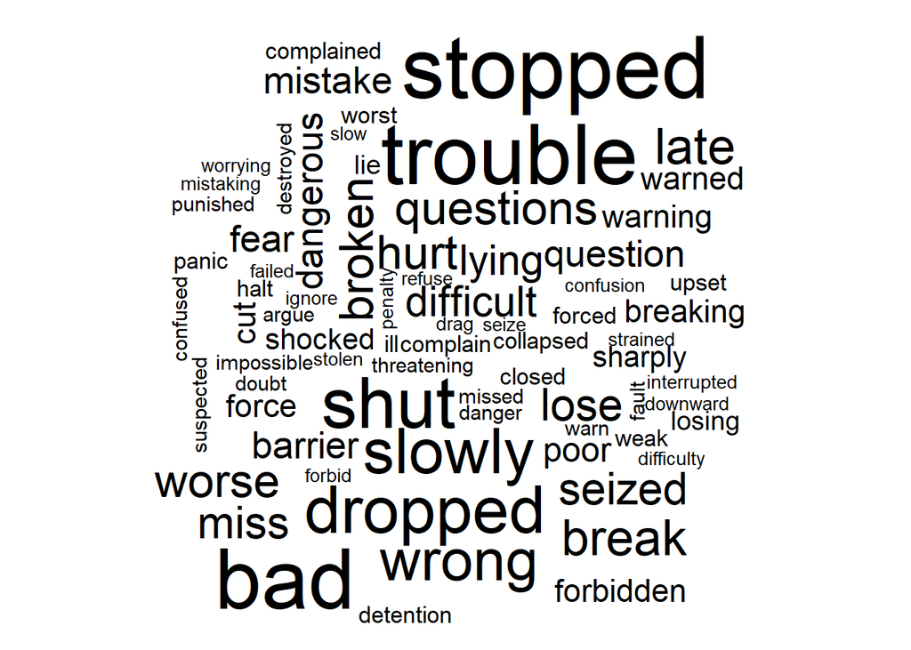

   ```r
   # Creating a dataset for `negative` sentiment tokens:
   loughran.sentiments.negative <- loughran.sentiments %>%
     filter(sentiment == "negative")

   # Creating a dataset for `positive` sentiment tokens:
   loughran.sentiments.positive <- loughran.sentiments %>%
     filter(sentiment == "positive")

   # For negative tokens, we can use the inner_join() function to get all of the negative words from the book "Philosopher's Stone"; we will then count each frequency of the word occurnaces and plot on a wordcloud:
   series.main %>%
    filter(book == "Philosopher's Stone" ) %>%
     inner_join(loughran.sentiments.negative) %>%
     count(word) %>%
     with(wordcloud(word, n, max.words = 100 ))
   ```

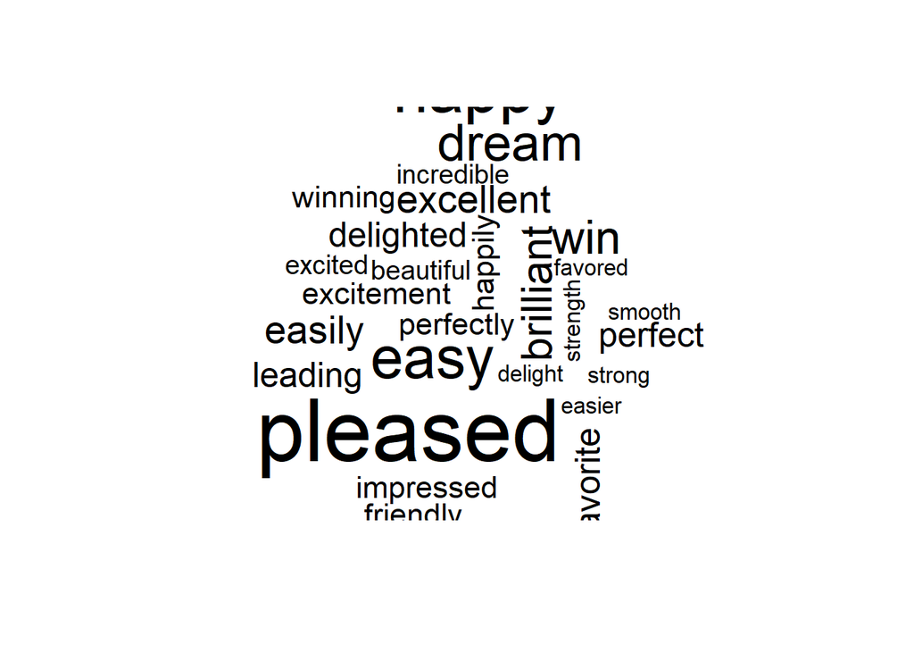

   ```r
   # We will repeat the above steps for positive tokens and plot similarly on a wordcloud:
   series.main %>%
    filter(book == "Philosopher's Stone" ) %>%
     inner_join(loughran.sentiments.positive) %>%
     count(word) %>%
     with(wordcloud(word, n, max.words = 100 ))
   ```

   *We can see there are more negative words then positive words in the first Book.*
3. Chapter wise Sentiments score:

   ```r
   # We will just take the positive and negative sentiments across all books in the series chappter wise grouped:
   series.main.sentiment <- series.main %>%
     inner_join(loughran.sentiments) %>%
     count(book, index = chapter %/% 1, sentiment) %>%
     spread(sentiment, n, fill = 0) %>%
     mutate(sentiment = positive - negative)

   series.main.sentiment
   ```

   ```
   ## # A tibble: 200 x 9
   ##    book  index constraining litigious negative positive superfluous uncertainty
   ##    <fct> <dbl>        <dbl>     <dbl>    <dbl>    <dbl>       <dbl>       <dbl>
   ##  1 Deat~     1            4         2       47       20           0          10
   ##  2 Deat~     2            1        11       85       26           0          16
   ##  3 Deat~     3            0         2       45       10           0           7
   ##  4 Deat~     4            2         1       59        7           0           9
   ##  5 Deat~     5            1         4       85        5           0          16
   ##  6 Deat~     6            6         3       92       25           0          19
   ##  7 Deat~     7            2         5       75       33           0          18
   ##  8 Deat~     8            1         4       63       30           0          15
   ##  9 Deat~     9            1         3       51        4           0           4
   ## 10 Deat~    10            8         2       75       28           0          11
   ## # ... with 190 more rows, and 1 more variable: sentiment <dbl>
   ```

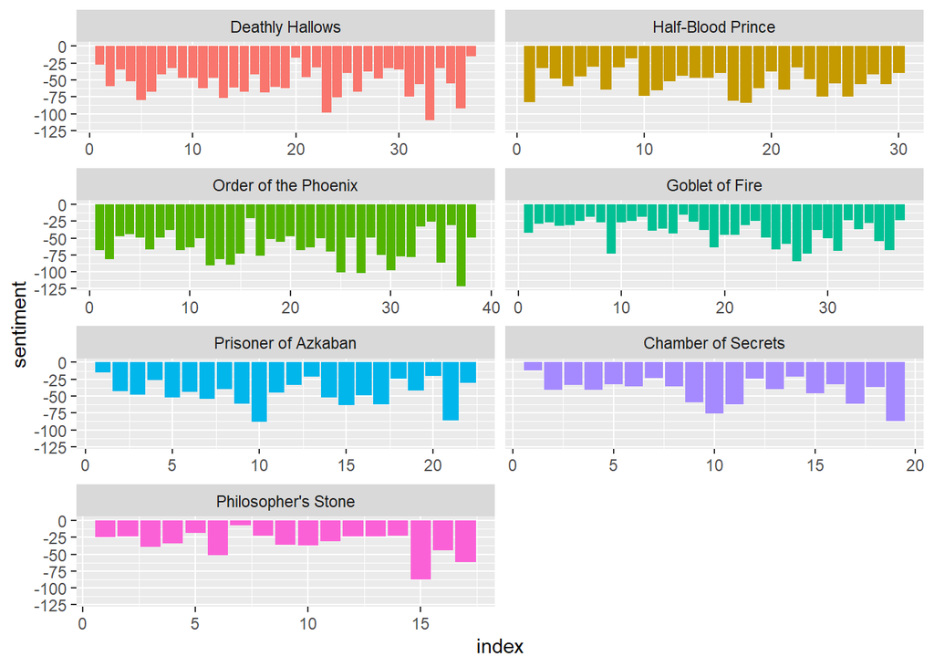

   ```r
   # We can now plot it to visualize the spread of the sentiments:
   ggplot(series.main.sentiment, aes(index, sentiment, fill = book)) +
     geom_col(show.legend = FALSE) +
     facet_wrap(~book, ncol = 2, scales = "free_x")
   ```

   *From the ggplot and the table data above, we can see that the book overall is more negative then postive score for each chapter; the books are not for smaller children perhaps.*
4. Top words across all sentiments in all books:

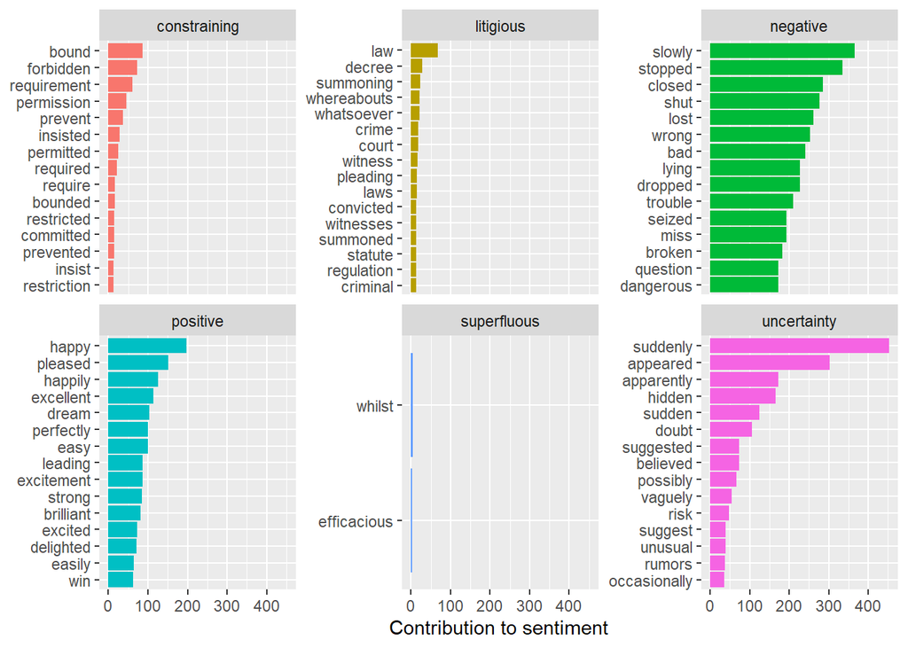

   ```r
   # Below runs across all the books in the series for all sentiments types and plots the top 15 words per sentiment category for the entie series:
   series.main %>%
     inner_join(loughran.sentiments) %>%
     count(word, sentiment, sort = TRUE) %>%
     ungroup()  %>%
     group_by(sentiment) %>%
     top_n(15) %>%
     ungroup() %>%
     mutate(word = reorder(word, n)) %>%
     ggplot(aes(word, n, fill = sentiment)) +
     geom_col(show.legend = FALSE) +
     facet_wrap(~sentiment, scales = "free_y") +
     labs(y = "Contribution to sentiment",
          x = NULL) +
     coord_flip()
   ```

   *We can conlude by saying that harry potter did have a adventurous but a thrilling life. Rightly fits into the genre of Fantasy, drama, young adult fiction, mystery, and thriller [[wikipedia link](https://en.wikipedia.org/wiki/Harry_Potter)]*